# Count Regression: Workflow

Poisson, negative binomial, and probing interactions with biochemist publications

Author

Selena Esteves

## Purpose

This report demonstrates a complete count-regression workflow. We will use the publications dataset from class.

Our objectives are to:

1. Describe the outcome and see why a linear model fails
2. Build up a Poisson model
3. Check it with DHARMa, find overdispersion, and move to a negative binomial (NB)
4. Check whether the zeros need their own model
5. Add an interaction, test it, and probe it with **ggeffects** and **emmeans**
6. Write up the results

## 1. Load packages and prepare the data

Install any missing packages **once in the R Console**

The `bioChemists` data (Long, 1990) follow 915 biochemistry PhD students and count the articles each published in the last three years of their PhD.

| Variable | Description |
| --- | --- |
| `art` | **Outcome:** articles published in the last 3 years of the PhD |
| `fem` | Gender: `Men` or `Women` |
| `mar` | Marital status: `Single` or `Married` |
| `kid5` | Number of children aged 5 or younger |
| `phd` | Prestige of the PhD department |
| `ment` | Articles published by the student’s mentor in the last 3 years |

Reference groups are **Men** and **Single**.

## 2. Explore the data

It is important to familiarize yourself with the data.

```
    n     mean      var    p_zero max
1 915 1.692896 3.709742 0.3005464  19
```

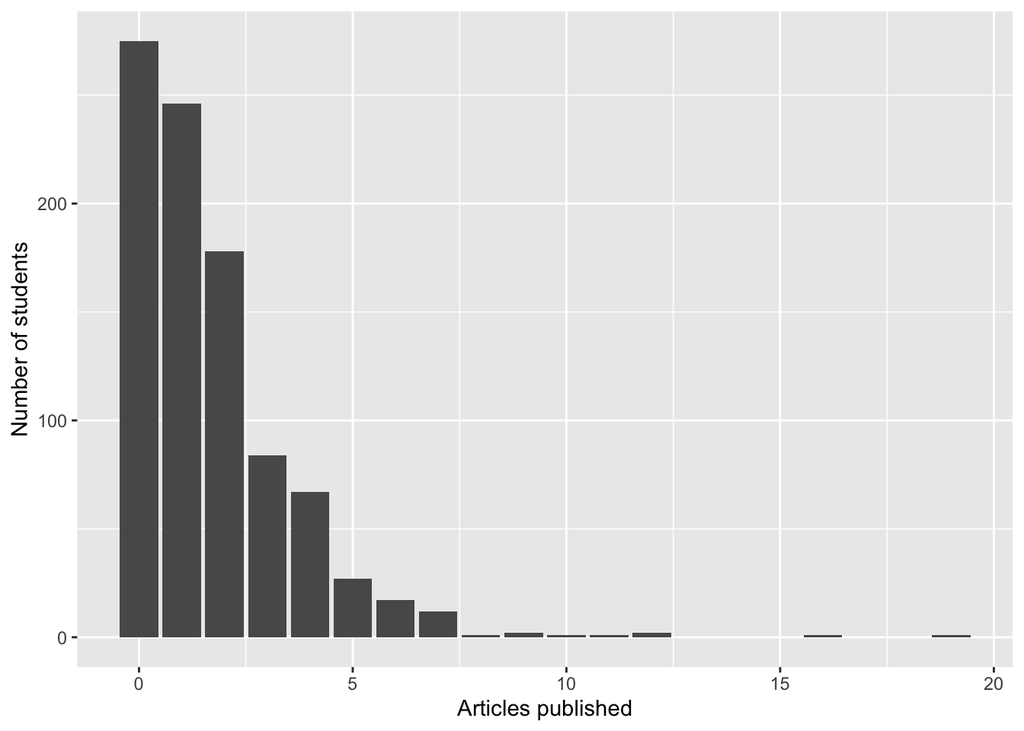

Three things stand out:

- **It’s a count.** Whole numbers, bounded at zero, and right-skewed.
- **The variance (3.71) is about 2.19 times the mean (1.69).** A Poisson assumes these are equal, so we should expect overdispersion.
- **30% of students published nothing.** We’ll need to check whether our model can reproduce that many zeros.

## 3. Why not a linear model?

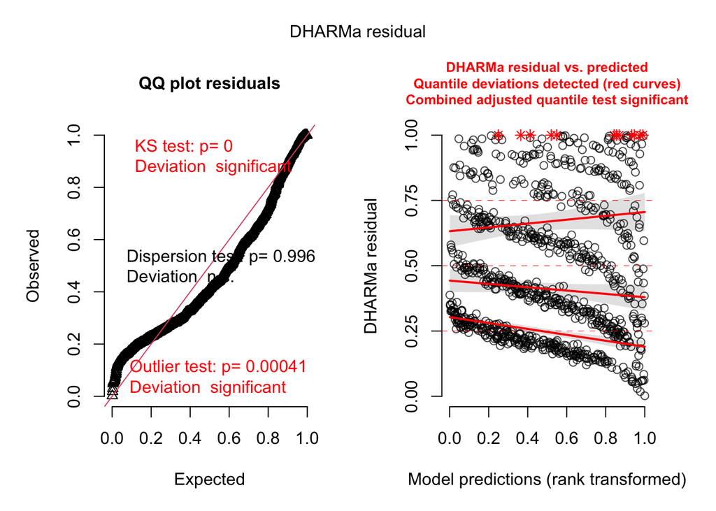

DHARMa simulates new data from the fitted model and asks where each observed value falls among the simulations. If the model is right, these scaled residuals are uniform between 0 and 1: the QQ plot follows the diagonal and the residual-vs-predicted plot is flat.

The Gaussian model fails these checks, and it has deeper problems too:

- It can predict negative article counts.
- It assumes constant variance, but count variance grows with the mean.
- It treats effects as additive, when it’s more natural for a predictor to multiply the expected count.

## 4. Poisson Models

We will fit an intercept-only model and two increasingly complex substantive models.

| Model | Formula | Research rationale |
| --- | --- | --- |
| null: Null | `art ~ 1` | Baseline model |
| one_pred: Mentor | `art ~ ment` | Article counts vary with mentor publishing |
| full poisson: Full | `art ~ fem + mar + kid5 + phd + ment` | Gender, marital status, young children, and PhD prestige explain additional variation |

The models are **nested**: each successive model contains all predictors from the preceding model, plus one or more additional predictors.

After executing the model-fitting code, explore the results, in the console only:

## 5. Nested Model Comparisons

We will evaluate the models. Our main performance metrics are:

- **AIC:** Evaluates model fit while penalizing model complexity. Lower values indicate a preferred balance between fit and complexity.
- **BIC:** Similar to AIC, but applies a stronger penalty for model complexity. Lower values are preferred.
- **Likelihood-ratio test (χ²):** Tests whether adding predictors significantly improves model fit relative to the preceding model. A statistically significant p-value (p < .05) indicates that the additional predictors improve model fit.

### 5.1. Compare the models

Because our models are nested and estimated using the same observations, we can compare all three models in a single `anova()` call.

Each row represents a model. We can retain and rename the statistics relevant to our comparison table.

### 5.2. Extract overall model performance

The `glance()` function from the `broom.mixed` package returns a one-row data frame containing model-level statistics.

We can apply it to each fitted model.

We can then combine these results using `rbind()`.

### 5.3. Combine nested tests and model performance

Because the rows in `glances` and `tests` represent the same models in the same order, we can combine them using `cbind()`.

### 5.4. Display the combined model comparison table

| Model | AIC | BIC | Log-likelihood | Deviance | Residual.df | Nested df | Nested χ² | Nested p |
| --- | --- | --- | --- | --- | --- | --- | --- | --- |
| Null | 3,487.147 | 3,491.966 | −1,742.573 | 1,817.405 | 914 | — | — | — |
| One_Pred: Mentor | 3,341.286 | 3,350.924 | −1,668.643 | 1,669.545 | 913 | 1 | 147.860 | < .001 |
| Full | 3,314.113 | 3,343.026 | −1,651.056 | 1,634.371 | 909 | 4 | 35.174 | < .001 |

### 5.5. Interpreting the combined table

Each row represents one fitted model.

When comparing models, we generally look for **lower AIC and BIC values** and whether the **likelihood-ratio test** **indicates a statistically significant improvement** in model fit.

Remember: The null row has no incremental comparison because it serves as the baseline.

## 6. Select a provisional model

Model selection requires considering both statistical evidence and model complexity.

In particular, we should consider:

- Nested-model χ²-tests.
- AIC.
- BIC.
- Model complexity.
- Diagnostic findings.
- Substantive interpretability.

For this demonstration, we will use the **likelihood-ratio test** as an initial selection criterion. We can see that the likelihood ratio test is still significant for our most complex model, mod3. Therefore we will select our model by `filter`ing by `Nested.p.value` and using `slice_tail()` to extract the last row in our comparison table.

The provisionally selected model is **Full**.

Its performance is:

- AIC = **3314.113**
- BIC = **3343.026**

We will now examine whether the selected model has important diagnostic problems.

## 7. Checking the Poisson

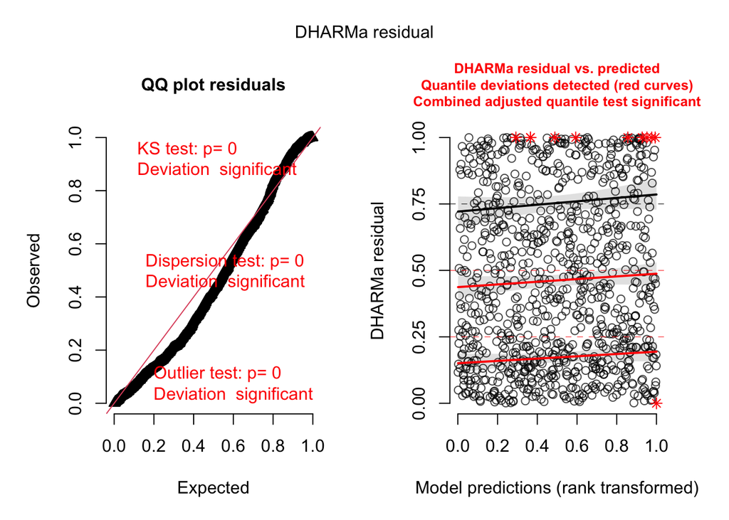

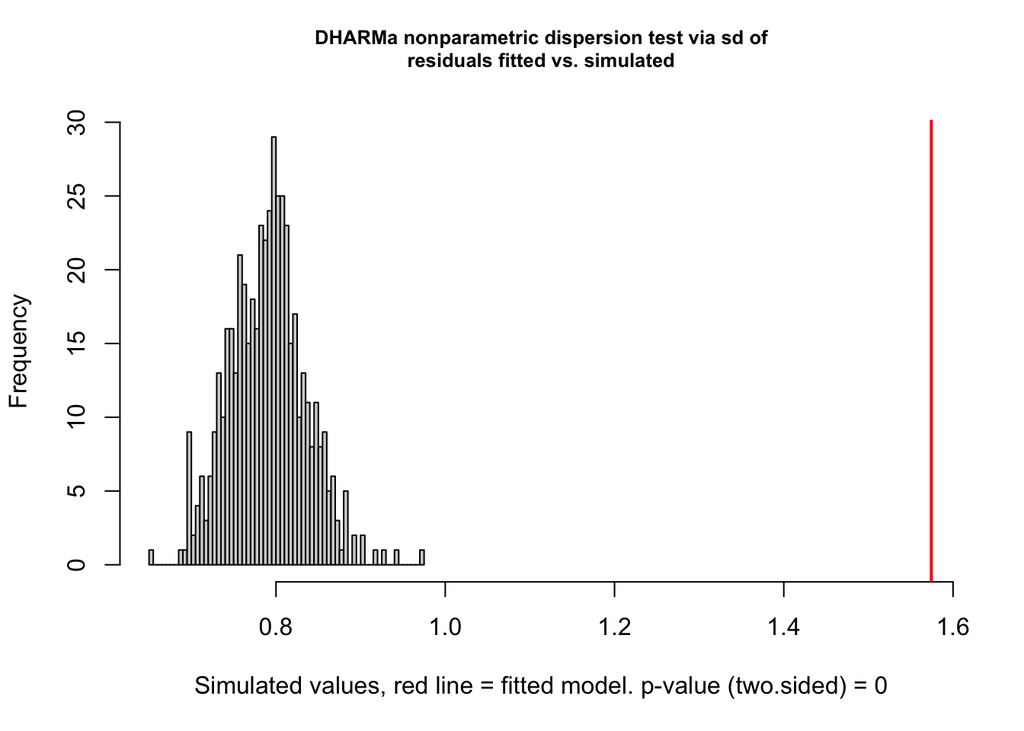

```
    DHARMa nonparametric dispersion test via sd of residuals fitted vs.
    simulated

data:  simulationOutput
dispersion = 1.9931, p-value < 2.2e-16
alternative hypothesis: two.sided
```

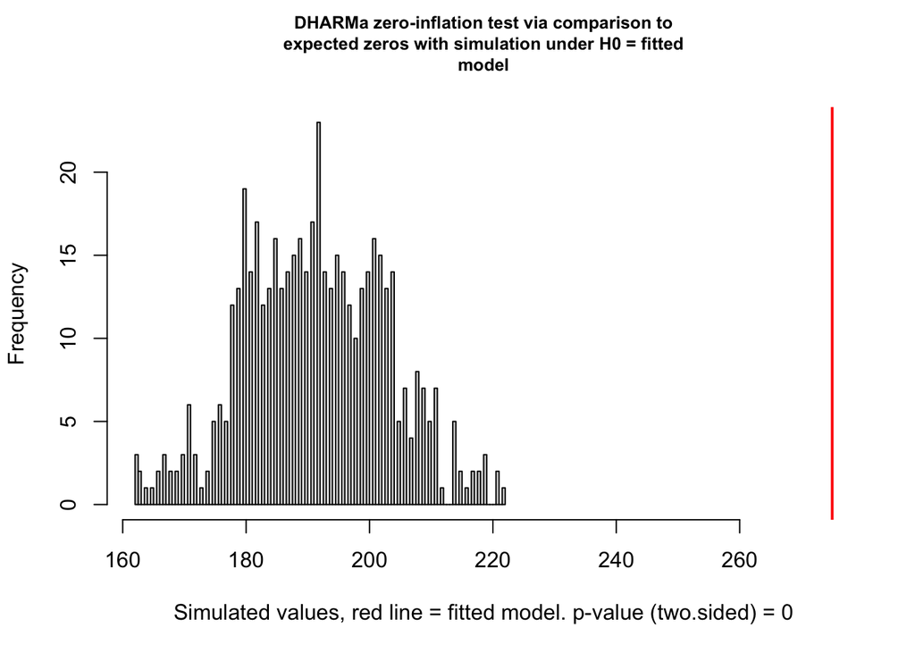

```
    DHARMa zero-inflation test via comparison to expected zeros with
    simulation under H0 = fitted model

data:  simulationOutput
ratioObsSim = 1.4363, p-value < 2.2e-16
alternative hypothesis: two.sided
```

The dispersion ratio is 1.99 (*p* < .001), and there are 1.44 times as many zeros as the Poisson expects. The observed data are more variable than a Poisson allows.

This matters because a Poisson’s standard errors assume variance = mean. When the data are overdispersed, those SEs are too small, CIs are too narrow, and *p*-values are too optimistic.

## 8. The negative binomial

In an effort to address this, a negative binomial model adds a dispersion parameter so the variance can exceed the mean. The Poisson is nested in the NB and we can compare them with a likelihood ratio test (LRT).

```
 Family: nbinom2  ( log )
Formula:          art ~ fem + mar + kid5 + phd + ment
Data: data

      AIC       BIC    logLik -2*log(L)  df.resid
   3135.9    3169.6   -1561.0    3121.9       908


Dispersion parameter for nbinom2 family (): 2.26

Conditional model:
            Estimate Std. Error z value Pr(>|z|)
(Intercept)  0.25614    0.13856   1.849 0.064515 .
femWomen    -0.21642    0.07267  -2.978 0.002901 **
marMarried   0.15049    0.08211   1.833 0.066823 .
kid5        -0.17641    0.05306  -3.325 0.000885 ***
phd          0.01527    0.03604   0.424 0.671759
ment         0.02908    0.00347   8.381  < 2e-16 ***
---
Signif. codes:  0 '***' 0.001 '**' 0.01 '*' 0.05 '.' 0.1 ' ' 1
```

```
Data: data
Models:
poisson: art ~ fem + mar + kid5 + phd + ment, zi=~0, disp=~1
neg_binom: art ~ fem + mar + kid5 + phd + ment, zi=~0, disp=~1
          Df    AIC    BIC  logLik deviance Chisq Chi Df Pr(>Chisq)
poisson    6 3314.1 3343.0 -1651.1   3302.1
neg_binom  7 3135.9 3169.6 -1561.0   3121.9 180.2      1  < 2.2e-16 ***
---
Signif. codes:  0 '***' 0.001 '**' 0.01 '*' 0.05 '.' 0.1 ' ' 1
```

The negative binomial model fit significantly better than the full Poisson model, χ²(1) = 180.2, *p* < .001.

### 8a. Checking the NB

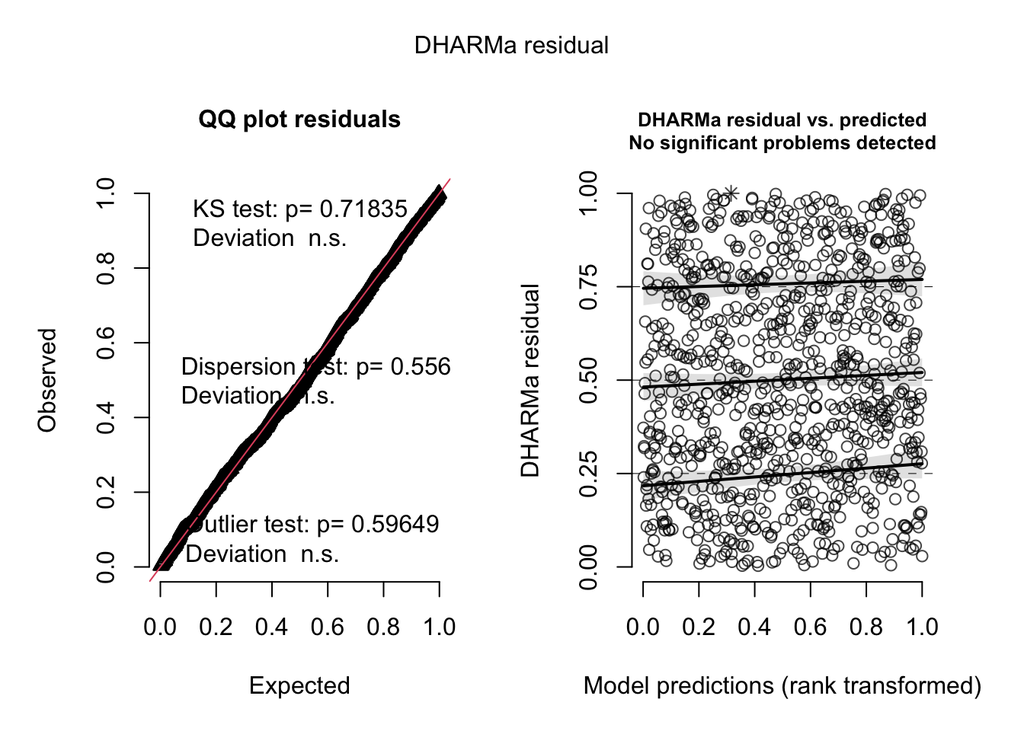

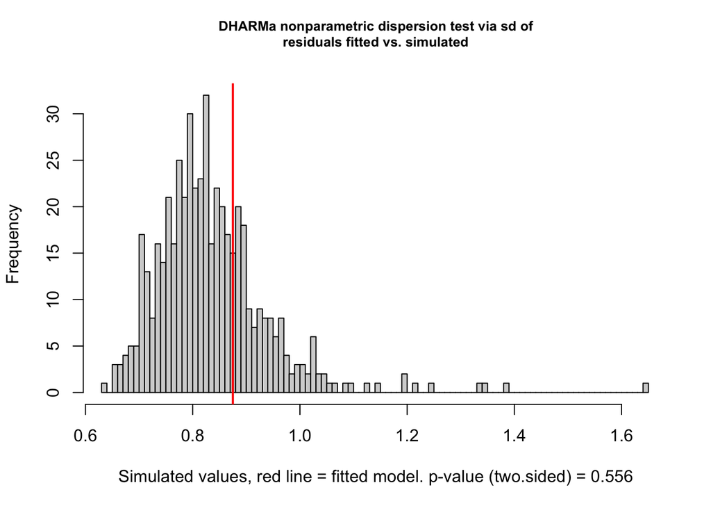

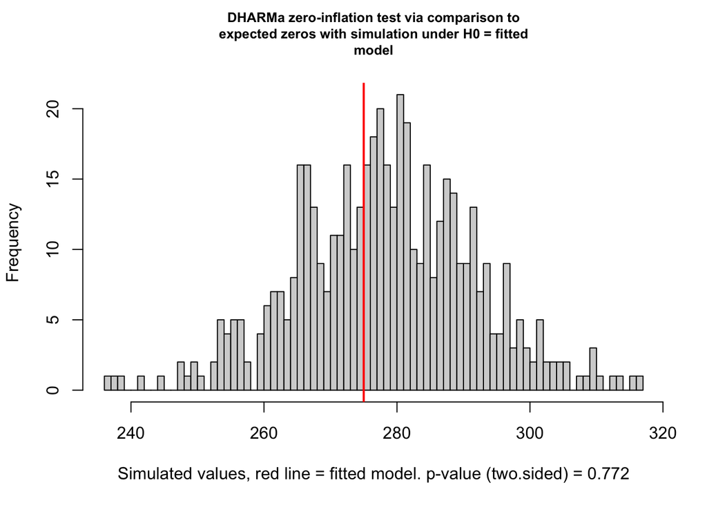

The NB resolved the overdispersion: the dispersion ratio is now 1.05 (*p* = 0.556), close to 1 and non-significant. We check the zeros in the next section.

### 8b. Visualize predicted counts

Coefficients on the log scale are hard to picture, so it helps to plot what the model predicts on the count scale. Here we plot predicted article counts across mentor productivity, holding the other predictors at their reference levels (Men, Single) or means (`kid5`, `phd`).

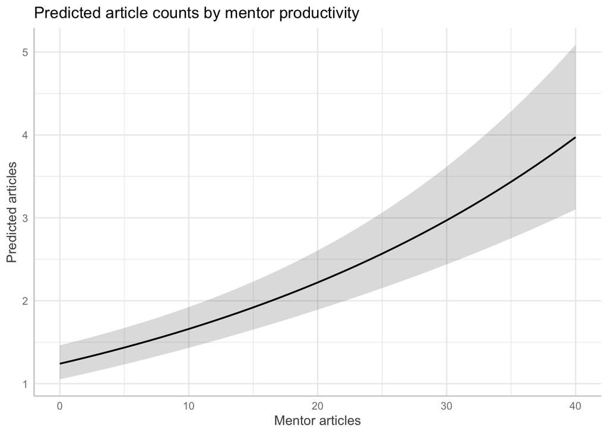

The line curves upward even though the model is linear in its predictors. That’s the log link: each additional mentor article adds a constant amount on the log scale, which multiplies the expected count, so the same one-article increase adds more articles when the expected count is already high.

## 9. Do the zeros need their own model?

Count data often have lots of zeros, but that alone doesn’t mean you need a special model for them. The question is whether there are **more zeros than your model predicts**.

We already answered that in 8a. The NB’s zero-inflation test showed the model reproduces the observed zeros well (observed/expected = 0.99, *p* = 0.772). The NB’s extra variance is enough to generate this many zeros, so **a separate model for zeros isn’t needed here, and we continue with the NB2.**

If DHARMa *had* flagged excess zeros after the NB, there are two families of models that give the zeros their own process:

- **Zero-inflated (ZIP/ZINB):** a mixture. Some zeros are “structural” (e.g., a student who would never publish), and the rest come from the count distribution, which can also produce zeros.
- **Hurdle:** a two-part model. One part decides zero vs. non-zero (“did they publish at all?”), and a truncated count distribution handles everything above zero (“if so, how much?”).

Here’s the code you’d use. It isn’t run in this document.

Here a zero inflation model was not necessary.

## 10. Adding an interaction: PhD prestige × gender

**Question:** Does the association between PhD department prestige and productivity differ for men and women?

### Step 1: Fit the model with the product term

```
 Family: nbinom2  ( log )
Formula:          art ~ ment + mar + kid5 + phd * fem
Data: data

      AIC       BIC    logLik -2*log(L)  df.resid
   3134.2    3172.7   -1559.1    3118.2       907


Dispersion parameter for nbinom2 family (): 2.29

Conditional model:
              Estimate Std. Error z value Pr(>|z|)
(Intercept)   0.446564   0.169500   2.635 0.008424 **
ment          0.029326   0.003469   8.453  < 2e-16 ***
marMarried    0.136115   0.082337   1.653 0.098300 .
kid5         -0.176594   0.052978  -3.333 0.000858 ***
phd          -0.042561   0.046811  -0.909 0.363238
femWomen     -0.651886   0.237175  -2.749 0.005986 **
phd:femWomen  0.137394   0.071172   1.930 0.053552 .
---
Signif. codes:  0 '***' 0.001 '**' 0.01 '*' 0.05 '.' 0.1 ' ' 1
```

### Step 2: Test whether it’s needed

```
Data: data
Models:
neg_binom: art ~ fem + mar + kid5 + phd + ment, zi=~0, disp=~1
interact: art ~ ment + mar + kid5 + phd * fem, zi=~0, disp=~1
          Df    AIC    BIC  logLik deviance  Chisq Chi Df Pr(>Chisq)
neg_binom  7 3135.9 3169.6 -1561.0   3121.9
interact   8 3134.2 3172.7 -1559.1   3118.2 3.7319      1    0.05338 .
---
Signif. codes:  0 '***' 0.001 '**' 0.01 '*' 0.05 '.' 0.1 ' ' 1
```

The interaction is not significant here (*p* = 0.053). We probe it below anyway.

### Step 3: Plot predicted counts with ggeffects

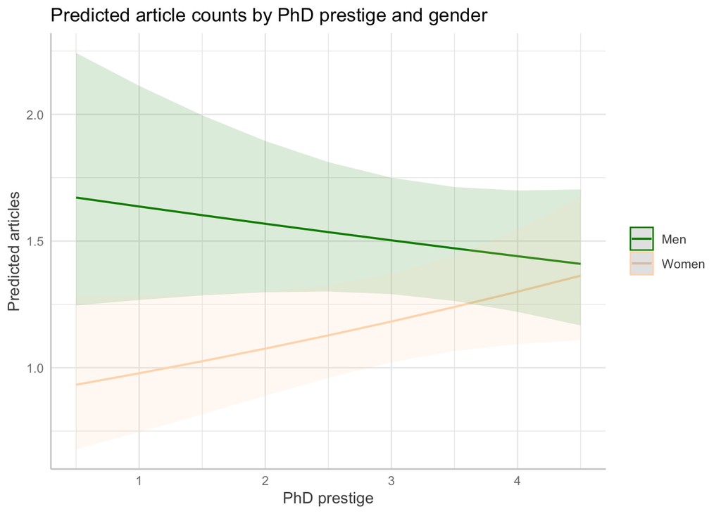

### Step 4a: Simple slopes with emmeans

The slope of `phd` within each gender, tested against zero, then compared.

```
 contrast    estimate     SE  df z.ratio p.value
 Men - Women   -0.137 0.0712 Inf  -1.930  0.0536

Results are averaged over the levels of: mar
```

```
 fem   phd.trend     SE  df asymp.LCL asymp.UCL z.ratio p.value
 Men     -0.0426 0.0468 Inf   -0.1343    0.0492  -0.909  0.3632
 Women    0.0948 0.0549 Inf   -0.0127    0.2024   1.729  0.0839

Results are averaged over the levels of: mar
Confidence level used: 0.95
```

The `pairs(slopes)` test reproduces the interaction coefficient from `summary(interact)` (with the sign flipped, since `pairs()` computes Men − Women). That’s expected: with a binary moderator, “do the slopes differ?” is exactly the question the product term answers.

### Step 4b: Simple effects at chosen values of prestige

Now flip it: the gender gap at low (−1 *SD*), average, and high (+1 *SD*) prestige.

```
phd = 2.12:
 fem   response     SE  df asymp.LCL asymp.UCL
 Men       1.81 0.1270 Inf      1.58      2.08
 Women     1.26 0.0995 Inf      1.08      1.47

phd = 3.10:
 fem   response     SE  df asymp.LCL asymp.UCL
 Men       1.74 0.0867 Inf      1.58      1.92
 Women     1.39 0.0757 Inf      1.25      1.54

phd = 4.09:
 fem   response     SE  df asymp.LCL asymp.UCL
 Men       1.67 0.1090 Inf      1.46      1.89
 Women     1.52 0.1140 Inf      1.31      1.76

Results are averaged over the levels of: mar
Confidence level used: 0.95
Intervals are back-transformed from the log scale
```

```
phd = 2.12:
 contrast    estimate     SE  df z.ratio p.value
 Men - Women   0.3608 0.1040 Inf   3.456  0.0005

phd = 3.10:
 contrast    estimate     SE  df z.ratio p.value
 Men - Women   0.2255 0.0728 Inf   3.099  0.0019

phd = 4.09:
 contrast    estimate     SE  df z.ratio p.value
 Men - Women   0.0903 0.0975 Inf   0.926  0.3545

Results are averaged over the levels of: mar
Results are given on the log (not the response) scale.
```

**Why don’t these counts match the plot exactly?** ggeffects (Step 3) holds `mar` at its reference level (Single), while emmeans *averages over* Single and Married (see “Results are averaged over the levels of: mar” in the output). Both are valid; they just answer slightly different questions. The gender *contrasts* are the same either way, because with no interaction involving `mar` its effect cancels out of the comparison.

### Step 5: Report the simple effects in a table

Simple Effects of Gender Across PhD Prestige

Negative-binomial regression (log link)

| PhD Prestige | Contrast | Log Contrast | SE | z | p |
| --- | --- | --- | --- | --- | --- |
| -1 SD | Men - Women | 0.361 | 0.104 | 3.456 | <0.001 |
| Mean | Men - Women | 0.226 | 0.073 | 3.099 | 0.002 |
| +1 SD | Men - Women | 0.090 | 0.098 | 0.926 | 0.354 |

Log contrasts = Men − Women. z-tests and p-values are computed on the log scale.

## 11. Results write-up

Article counts were overdispersed (*M* = 1.69, *s*² = 3.71; 30% zeros). Simulation-based residual checks on a Poisson model showed significant overdispersion (dispersion ratio = 1.99, *p* < .001) and excess zeros (observed/expected = 1.44, *p* < .001). A negative binomial model fit significantly better, χ²(1) = 180.20, *p* < .001, and showed no remaining evidence of overdispersion (ratio = 1.05, *p* = .556) or excess zeros (ratio = 0.99, *p* = .772), so no separate model for zeros was needed.

Holding other predictors constant, women published fewer articles than men (*b* = −0.22, 95% CI [−0.36, −0.07], *p* = .003). Each additional child aged 5 or younger was associated with fewer articles (*b* = −0.18, 95% CI [−0.28, −0.07], *p* < .001), and each additional mentor article with more articles (*b* = 0.029, 95% CI [0.023, 0.035], *p* < .001). Marital status (*b* = 0.15, 95% CI [−0.01, 0.31], *p* = .067) and PhD prestige (*b* = 0.02, 95% CI [−0.06, 0.09], *p* = .672) were not significantly associated with article counts.

Adding a PhD prestige × gender interaction did not significantly improve fit, χ²(1) = 3.73, *p* = .053. Simple slopes showed that prestige was not significantly associated with article counts for men (*b* = −0.04, 95% CI [−0.14, 0.05], *p* = .363) or women (*b* = 0.10, 95% CI [−0.01, 0.20], *p* = .084). Simple effects, however, showed that the gender gap narrowed as prestige increased. Men were expected to publish more articles than women at low prestige (−1 *SD*; *b* = 0.36, *p* < .001) and at average prestige (*b* = 0.22, *p* = .002), but the difference was not significant at high prestige (+1 *SD*; *b* = 0.09, *p* = .354).

## Reference

Long, J. S. (1990). The origins of sex differences in science. *Social Forces, 68*(4), 1297–1316.